# Chapter 3

*Logistic regression*

```r
url <- "http://s3.amazonaws.com/assets.datacamp.com/production/course_2218/datasets"
url_math <- paste(url, "student-mat.csv", sep = "/")
url_math
```

```
## [1] "http://s3.amazonaws.com/assets.datacamp.com/production/course_2218/datasets/student-mat.csv"
```

```r
math <- read.table(url_math, sep = ";" , header=TRUE)
url_por <- paste(url, "student-por.csv", sep ="/")
url_por
```

```
## [1] "http://s3.amazonaws.com/assets.datacamp.com/production/course_2218/datasets/student-por.csv"
```

```r
por <- read.table(url_por, sep = ";", header = TRUE)
colnames(math)
```

```
##  [1] "school"     "sex"        "age"        "address"    "famsize"
##  [6] "Pstatus"    "Medu"       "Fedu"       "Mjob"       "Fjob"
## [11] "reason"     "guardian"   "traveltime" "studytime"  "failures"
## [16] "schoolsup"  "famsup"     "paid"       "activities" "nursery"
## [21] "higher"     "internet"   "romantic"   "famrel"     "freetime"
## [26] "goout"      "Dalc"       "Walc"       "health"     "absences"
## [31] "G1"         "G2"         "G3"
```

```r
colnames(por)
```

```
##  [1] "school"     "sex"        "age"        "address"    "famsize"
##  [6] "Pstatus"    "Medu"       "Fedu"       "Mjob"       "Fjob"
## [11] "reason"     "guardian"   "traveltime" "studytime"  "failures"
## [16] "schoolsup"  "famsup"     "paid"       "activities" "nursery"
## [21] "higher"     "internet"   "romantic"   "famrel"     "freetime"
## [26] "goout"      "Dalc"       "Walc"       "health"     "absences"
## [31] "G1"         "G2"         "G3"
```

#Description: The data refers to the achievements of students of two Portugese schools (secondary education). The data includes information concerning students’ grades, their background, alcohol consumption level etc.

#Hypothesis: #1. The inhabitants of rural areas consume more alcohol that those living in urban zones. #2. Age-gender relationship. The alcohol consumption is higher amongst men than women. Men start drinking earlier that women. #3. The extra-curricular activities can be correlated with the lower level of alcohol consumption. #4. Going out can be associated with higher level of drinking.

```r
# math and por are available

# access the dplyr library
library(dplyr)
# common columns to use as identifiers
join_by <- c("school","sex","age","address","famsize","Pstatus","Medu","Fedu","Mjob","Fjob","reason","nursery","internet")

# join the two datasets by the selected identifiers
math_por <- inner_join(math, por, by = join_by, suffix = c(".math", ".por"))

# see the new column names
colnames(math_por)
```

```
##  [1] "school"          "sex"             "age"
##  [4] "address"         "famsize"         "Pstatus"
##  [7] "Medu"            "Fedu"            "Mjob"
## [10] "Fjob"            "reason"          "guardian.math"
## [13] "traveltime.math" "studytime.math"  "failures.math"
## [16] "schoolsup.math"  "famsup.math"     "paid.math"
## [19] "activities.math" "nursery"         "higher.math"
## [22] "internet"        "romantic.math"   "famrel.math"
## [25] "freetime.math"   "goout.math"      "Dalc.math"
## [28] "Walc.math"       "health.math"     "absences.math"
## [31] "G1.math"         "G2.math"         "G3.math"
## [34] "guardian.por"    "traveltime.por"  "studytime.por"
## [37] "failures.por"    "schoolsup.por"   "famsup.por"
## [40] "paid.por"        "activities.por"  "higher.por"
## [43] "romantic.por"    "famrel.por"      "freetime.por"
## [46] "goout.por"       "Dalc.por"        "Walc.por"
## [49] "health.por"      "absences.por"    "G1.por"
## [52] "G2.por"          "G3.por"
```

```r
# glimpse at the data
glimpse(math_por)
```

```
## Observations: 382
## Variables: 53
## $ school          <fct> GP, GP, GP, GP, GP, GP, GP, GP, GP, GP, GP, GP...
## $ sex             <fct> F, F, F, F, F, M, M, F, M, M, F, F, M, M, M, F...
## $ age             <int> 18, 17, 15, 15, 16, 16, 16, 17, 15, 15, 15, 15...
## $ address         <fct> U, U, U, U, U, U, U, U, U, U, U, U, U, U, U, U...
## $ famsize         <fct> GT3, GT3, LE3, GT3, GT3, LE3, LE3, GT3, LE3, G...
## $ Pstatus         <fct> A, T, T, T, T, T, T, A, A, T, T, T, T, T, A, T...
## $ Medu            <int> 4, 1, 1, 4, 3, 4, 2, 4, 3, 3, 4, 2, 4, 4, 2, 4...
## $ Fedu            <int> 4, 1, 1, 2, 3, 3, 2, 4, 2, 4, 4, 1, 4, 3, 2, 4...
## $ Mjob            <fct> at_home, at_home, at_home, health, other, serv...
## $ Fjob            <fct> teacher, other, other, services, other, other,...
## $ reason          <fct> course, course, other, home, home, reputation,...
## $ guardian.math   <fct> mother, father, mother, mother, father, mother...
## $ traveltime.math <int> 2, 1, 1, 1, 1, 1, 1, 2, 1, 1, 1, 3, 1, 2, 1, 1...
```

[output cut: 40 more lines]

```r
# dplyr, math_por, join_by are available

# print out the column names of 'math_por'
colnames(math_por)
```

```
##  [1] "school"          "sex"             "age"
##  [4] "address"         "famsize"         "Pstatus"
##  [7] "Medu"            "Fedu"            "Mjob"
## [10] "Fjob"            "reason"          "guardian.math"
## [13] "traveltime.math" "studytime.math"  "failures.math"
## [16] "schoolsup.math"  "famsup.math"     "paid.math"
## [19] "activities.math" "nursery"         "higher.math"
## [22] "internet"        "romantic.math"   "famrel.math"
## [25] "freetime.math"   "goout.math"      "Dalc.math"
## [28] "Walc.math"       "health.math"     "absences.math"
## [31] "G1.math"         "G2.math"         "G3.math"
## [34] "guardian.por"    "traveltime.por"  "studytime.por"
## [37] "failures.por"    "schoolsup.por"   "famsup.por"
## [40] "paid.por"        "activities.por"  "higher.por"
## [43] "romantic.por"    "famrel.por"      "freetime.por"
## [46] "goout.por"       "Dalc.por"        "Walc.por"
## [49] "health.por"      "absences.por"    "G1.por"
## [52] "G2.por"          "G3.por"
```

```r
# create a new data frame with only the joined columns
alc <- select(math_por, one_of(join_by))

# columns that were not used for joining the data
notjoined_columns <- colnames(math)[!colnames(math) %in% join_by]

# print out the columns not used for joining
notjoined_columns
```

```
##  [1] "guardian"   "traveltime" "studytime"  "failures"   "schoolsup"
##  [6] "famsup"     "paid"       "activities" "higher"     "romantic"
## [11] "famrel"     "freetime"   "goout"      "Dalc"       "Walc"
## [16] "health"     "absences"   "G1"         "G2"         "G3"
```

```r
# for every column name not used for joining...
for(column_name in notjoined_columns) {
  # select two columns from 'math_por' with the same original name
  two_columns <- select(math_por, starts_with(column_name))
  # select the first column vector of those two columns
  first_column <- select(two_columns, 1)[[1]]

  # if that first column  vector is numeric...
  if(is.numeric(first_column)) {
    # take a rounded average of each row of the two columns and
    # add the resulting vector to the alc data frame
    alc[column_name] <- round(rowMeans(two_columns))
  } else { # else if it's not numeric...
    # add the first column vector to the alc data frame
    alc[column_name] <- first_column
  }
}

# glimpse at the new combined data
glimpse(alc)
```

```
## Observations: 382
## Variables: 33
## $ school     <fct> GP, GP, GP, GP, GP, GP, GP, GP, GP, GP, GP, GP, GP,...
## $ sex        <fct> F, F, F, F, F, M, M, F, M, M, F, F, M, M, M, F, F, ...
## $ age        <int> 18, 17, 15, 15, 16, 16, 16, 17, 15, 15, 15, 15, 15,...
## $ address    <fct> U, U, U, U, U, U, U, U, U, U, U, U, U, U, U, U, U, ...
## $ famsize    <fct> GT3, GT3, LE3, GT3, GT3, LE3, LE3, GT3, LE3, GT3, G...
## $ Pstatus    <fct> A, T, T, T, T, T, T, A, A, T, T, T, T, T, A, T, T, ...
## $ Medu       <int> 4, 1, 1, 4, 3, 4, 2, 4, 3, 3, 4, 2, 4, 4, 2, 4, 4, ...
## $ Fedu       <int> 4, 1, 1, 2, 3, 3, 2, 4, 2, 4, 4, 1, 4, 3, 2, 4, 4, ...
## $ Mjob       <fct> at_home, at_home, at_home, health, other, services,...
## $ Fjob       <fct> teacher, other, other, services, other, other, othe...
## $ reason     <fct> course, course, other, home, home, reputation, home...
## $ nursery    <fct> yes, no, yes, yes, yes, yes, yes, yes, yes, yes, ye...
## $ internet   <fct> no, yes, yes, yes, no, yes, yes, no, yes, yes, yes,...
```

[output cut: 20 more lines]

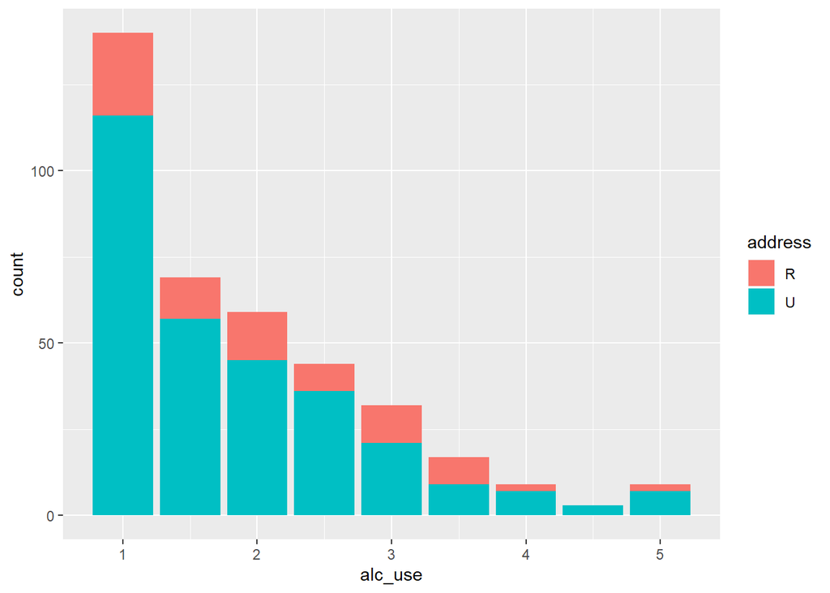

```r
# alc is available

# access the 'tidyverse' packages dplyr and ggplot2
library(dplyr); library(ggplot2)

# define a new column alc_use by combining weekday and weekend alcohol use
alc <- mutate(alc, alc_use = (Dalc + Walc) / 2)

# initialize a plot of alcohol use
g1 <- ggplot(data = alc, aes(x = alc_use, fill = address))

# define the plot as a bar plot and draw it
g1 + geom_bar()
```

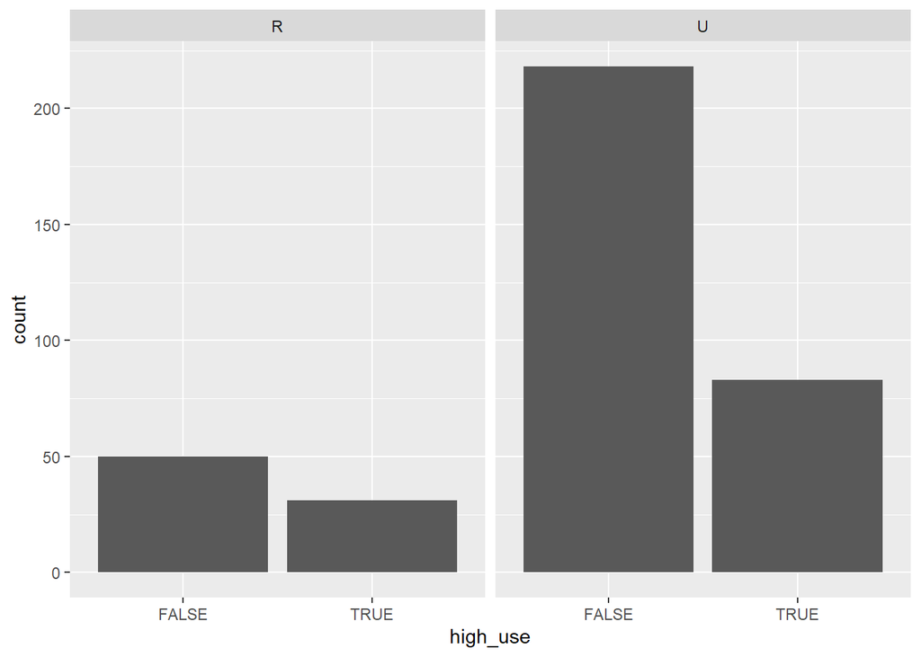

```r
# define a new logical column 'high_use'
alc <- mutate(alc, high_use = alc_use > 2)

# initialize a plot of 'high_use'
g2 <- ggplot(alc, aes(high_use))

# draw a bar plot of high_use by
g2 + facet_wrap("address") + geom_bar()
```